# NumPy tutorial

## NumPy

NumPy (short for **Num**erical **Py**thon) was created by Travis Oliphant in 2005. Since then, the open source NumPy library has evolved into an essential library for scientific computing in Python and has become a building block of many other scientific libraries, such as SciPy, Scikit-learn, Pandas, and others. What makes NumPy so particularly attractive to the scientific community is that it provides a convenient Python interface for working with multi-dimensional array data structures efficiently; the NumPy array data structure is also called `ndarray`, which is short for *n*-dimensional array.

Mathematical operations on NumPy’s ndarray objects are up to 50x faster than iterating over native Python lists using loops. NumPy arrays consume less memory than lists. The efficiency gains are primarily due to NumPy storing array elements in an ordered single location within memory. The efficiency advantages become particularly apparent when operating on arrays with thousands or millions of elements, which are pretty standard within data science. However, the computational efficiency and low-memory footprint come at a cost: NumPy arrays have a fixed size and are homogeneous, which means that all elements must have the same type.

[Learn more about NumPy here!](https://numpy.org/doc/stable/user/whatisnumpy.html)

### Installation

To check if you already have NumPy installed in your Python installation (it most likely is), run the following command:

```python
import numpy as np
```

If no error message is returned, that's a good sign NumPy is already available. If you get an error message like

*ModuleNotFoundError: No module named 'numpy'*

This probably means that NumPy needs to be installed first, If you use the pip Python package manager, the required command is 'pip install numpy'. If you need more detailed installation instructions, refer to https://numpy.org/.

We shorten “numpy” to “np” in order to save time and also to keep code standardized so that anyone working with your code can easily understand and run it.

### N-dimensional Arrays

NumPy is built around [`ndarrays`](https://docs.scipy.org/doc/numpy/reference/generated/numpy.ndarray.html) objects, which are high-performance multi-dimensional array data structures. Intuitively, we can think of a one-dimensional NumPy array as a data structure to represent a vector of elements -- you may think of it as a fixed-size Python list where all elements share the same type. Similarly, we can think of a two-dimensional array as a data structure to represent a matrix or a Python list of lists.

It's entirely possible to have arrays with many dimensions, including so many dimensions that it's no longer humanly possible to conceptualize them. We will focus on lower-dimensional arrays for the purpose of illustration in this introduction.

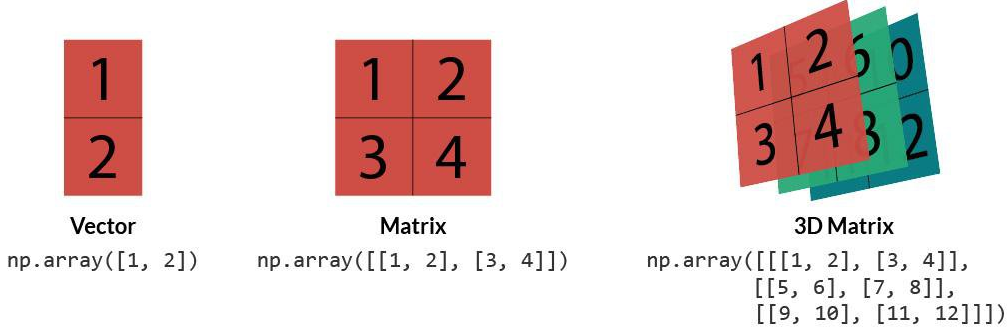

Now, let us get started with NumPy by calling the `array` function to create a two-dimensional NumPy array, consisting of two rows and three columns, from a list of lists:

```python
lst = [[1, 2, 3], [4, 5, 6]]
ary2d = np.array(lst)
ary2d
```

```
array([[1, 2, 3],
       [4, 5, 6]])
```

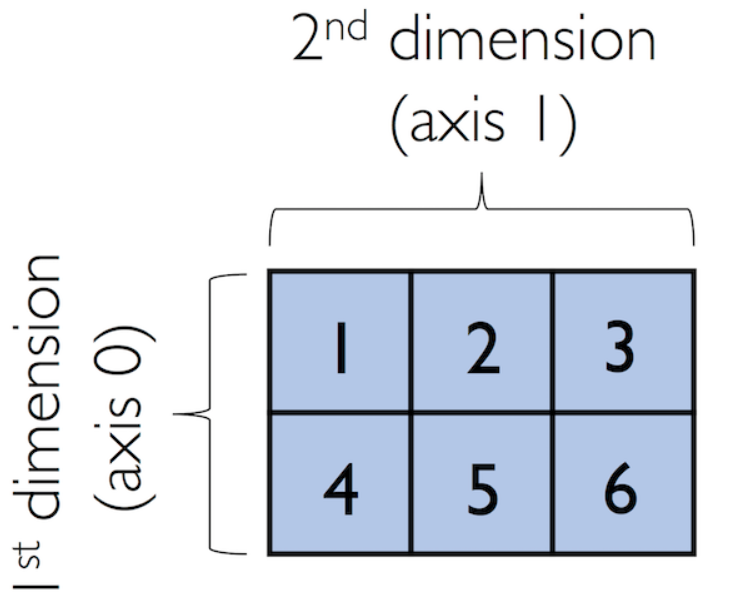

```python
ary2d.dtype
```

```
dtype('int32')
```

If we want to construct NumPy arrays of different types, we can pass an argument to the `dtype` parameter of the `array` function, for example `np.int32` to create 32-bit arrays. For a full list of supported data types, please refer to the official [NumPy documentation](https://docs.scipy.org/doc/numpy/user/basics.types.html). Once an array has been constructed, we can downcast or recast its type via the `astype` method as shown in the following example:

```python
float32_ary = ary2d.astype(np.float32)
float32_ary
```

```
array([[1., 2., 3.],
       [4., 5., 6.]], dtype=float32)
```

```python
float32_ary.dtype
```

```
dtype('float32')
```

To return the number of elements in an array, we can use the `size` attribute, as shown below:

```python
ary2d.size
```

```
6
```

And the number of dimensions of our array, called the *rank* of the array, can be obtained via the `ndim` attribute:

```python
ary2d.ndim
```

```
2
```

If we are interested in the number of elements along each array dimension (in the context of NumPy arrays, we may also refer to them as *axes*), we can access the `shape` attribute as shown below:

```python
ary2d.shape
```

```
(2, 3)
```

The `shape` is always a tuple; in the code example above, the two-dimensional `ary2d` object has two *rows* and three *columns*, `(2, 3)`, if we think of it as a matrix representation.

Similarly, the `shape` of the one-dimensional array only contains a single value:

```python
np.array([1, 2, 3]).shape
```

```
(3,)
```

### Array Construction Routines

This section provides a non-comprehensive list of array construction functions. Simple yet useful functions exist to construct arrays containing ones or zeros:

```python
np.ones((3, 3))
```

```
array([[1., 1., 1.],
       [1., 1., 1.],
       [1., 1., 1.]])
```

```python
np.zeros((3, 3))
```

```
array([[0., 0., 0.],
       [0., 0., 0.],
       [0., 0., 0.]])
```

Creating arrays of ones or zeros can also be useful as placeholder arrays, in cases where we do not want to use the initial values for computations but want to fill it with other values right away. If we do not need the initial values (for instance, `'0.'` or `'1.'`), there is also `np.empty`, which follows the same syntax. However, instead of filling the array with a particular value, the `empty` function creates the array with random values from memory. We can think of `zeros` as a function that creates the array via `empty` and then sets all its values to `0.`

NumPy also comes with functions to create identity matrices and diagonal matrices as `ndarrays` that can be useful in the context of linear algebra

```python
np.eye(3)
```

```
array([[1., 0., 0.],
       [0., 1., 0.],
       [0., 0., 1.]])
```

```python
np.diag((3, 3, 3))
```

```
array([[3, 0, 0],
       [0, 3, 0],
       [0, 0, 3]])
```

Lastly, I want to mention two very useful functions for creating sequences of numbers within a specified range, namely, `arange` and `linspace`. NumPy's `arange` function follows the same syntax as Python's `range` objects: If two arguments are provided, the first argument represents the start value and the second value defines the stop value of a half-open interval:

```python
np.arange(4., 10.)
```

```
array([4., 5., 6., 7., 8., 9.])
```

Notice that `arange` also performs type inference similar to the `array` function. If we only provide a single function argument, the range object treats this number as the endpoint of the interval and starts at 0:

```python
np.arange(5)
```

```
array([0, 1, 2, 3, 4])
```

Similar to Python's `range`, a third argument can be provided to define the *step* (the default step size is 1). For example, we can obtain an array of all uneven values between one and ten as follows:

```python
np.arange(1., 11., 2)
```

```
array([1., 3., 5., 7., 9.])
```

The `linspace` function is especially useful if we want to create a particular number of evenly spaced values in a specified interval:

```python
np.linspace(0., 1., num=5)
```

```
array([0.  , 0.25, 0.5 , 0.75, 1.  ])
```

[Learn more about creating arrays here.](https://numpy.org/doc/stable/user/basics.creation.html)

### Array Indexing

In this section, we will go over the basics of retrieving NumPy array elements via different indexing methods. Simple NumPy indexing and slicing works similar to Python lists

```python
data = np.array([1,2,3])

print(data[0])
print(data[1])
print(data[0:2])
print(data[1:])
print(data[-2:])
```

```
1
2
[1 2]
[2 3]
[2 3]
```

You can visualize it this way:

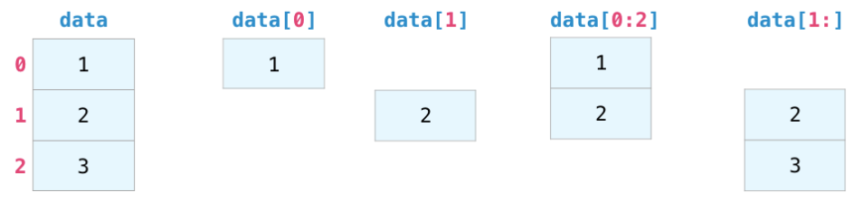

If we work with arrays that have more than one dimension or axis, we separate our indexing or slicing operations by commas as shown in the series of examples below:

```python
ary = np.array([[1, 2, 3],
                [4, 5, 6]])

ary[0, 0] # upper left
```

```
1
```

```python
ary[-1, -1] # lower right
```

```
6
```

```python
ary[0, 1] # first row, second column
```

```
2
```

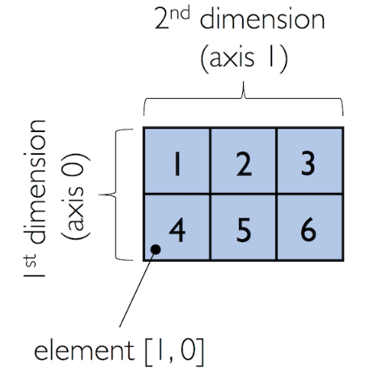

```python
ary[0] # entire first row, equivalent to ary[0, :]
```

```
array([1, 2, 3])
```

```python
ary[:, 0] # entire first column
```

```
array([1, 4])
```

```python
ary[:, :2] # first two columns
```

```
array([[1, 2],
       [4, 5]])
```

Here's another visual example of matrix indexing and slicing:

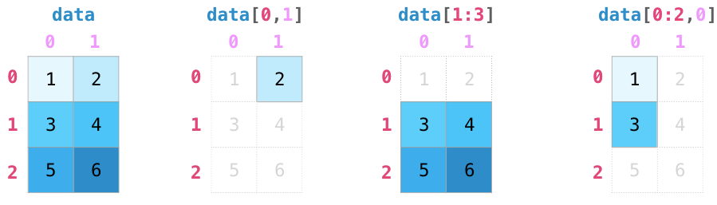

[Learn more about indexing on ndarrays.](https://numpy.org/doc/stable/user/basics.indexing.html)

### Array Math and Universal Functions

In the previous sections, you learned how to create NumPy arrays and how to access different elements in an array. It is time to introduce one of the core features of NumPy that makes working with `ndarray` so efficient and convenient: vectorization. While we typically use for-loops if we want to perform arithmetic operations on sequence-like objects, NumPy provides vectorized wrappers for performing element-wise operations implicitly via so-called *ufuncs* -- short for universal functions.

In this section, we will take a look at the most commonly used ufuncs, and I recommend you to check out the [official documentation](https://docs.scipy.org/doc/numpy/reference/ufuncs.html#available-ufuncs) for a complete list.

To provide an example of a simple ufunc for element-wise addition, consider the following example, where we add a scalar (here: 1) to each element in a nested Python list:

```python
lst = [[1, 2, 3], [4, 5, 6]]

for row_idx, row_val in enumerate(lst):
    for col_idx, col_val in enumerate(row_val):
        lst[row_idx][col_idx] += 1
lst
```

```
[[2, 3, 4], [5, 6, 7]]
```

This for-loop approach is very verbose, and we could achieve the same goal more elegantly using list comprehensions:

```python
lst = [[1, 2, 3], [4, 5, 6]]
[[cell + 1 for cell in row] for row in lst]
```

```
[[2, 3, 4], [5, 6, 7]]
```

We can accomplish the same using NumPy's ufunc for element-wise scalar addition as shown below:

```python
ary = np.array([[1, 2, 3], [4, 5, 6]])
ary = np.add(ary, 1)
ary
```

```
array([[2, 3, 4],
       [5, 6, 7]])
```

```python
ary + 1
```

```
array([[3, 4, 5],
       [6, 7, 8]])
```

```python
ary**2
```

```
array([[ 4,  9, 16],
       [25, 36, 49]], dtype=int32)
```

Naturally, we can also perform element-wise operations between arrays of equal dimensions:

```python
ary1 = np.array([1, 2, 3])
ary2 = np.array([4, 5, 6])

ary1 + ary2
```

```
array([5, 7, 9])
```

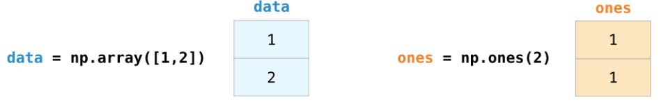

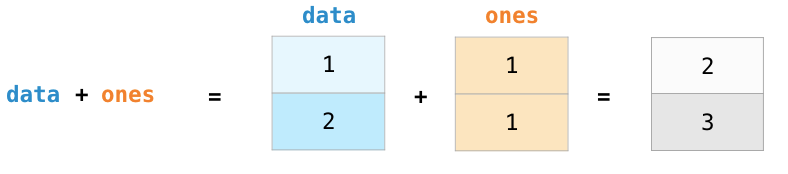

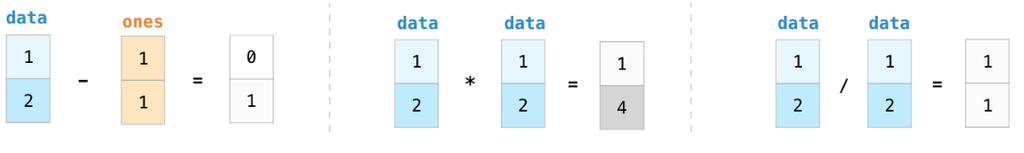

If we want to compute the sum of all the elements in the array, we can use the `sum` function. This works for 1D arrays, 2D arrays, and arrays in higher dimensions.

```python
ary = np.array([[1, 2, 3],
                [4, 5, 6]])

np.sum(ary) # column sums
ary.sum()
```

```
21
```

To add the rows or the columns in a two-dimensional array, you need to specify the axis. We can think of the first axis (`axis=0`) as the rows of a matrix. Thus, adding up elements along rows yields the sums of each column of that matrix:

```python
ary.sum(axis = 0) # column sums
```

```
array([5, 7, 9])
```

To compute the row sums of the array above, we can specify `axis=1`:

```python
ary.sum(axis = 1) # row sums
```

```
array([ 6, 15])
```

[figure not shown]

Other useful ufuncs are:

- `np.mean` (computes arithmetic average)
- `np.std` (computes the standard deviation)
- `np.sort` (sorts an array)
- `np.argsort` (returns indices that would sort an array)
- `np.min` (returns the minimum value of an array)
- `np.max` (returns the maximum value of an array)
- `np.argmin` (returns the index of the minimum value)
- `np.argmax` (returns the index of the maximum value)
- `np.array_equal` (checks if two arrays have the same shape and elements)

Here's another visual example of matrix aggregation using the `max` function:

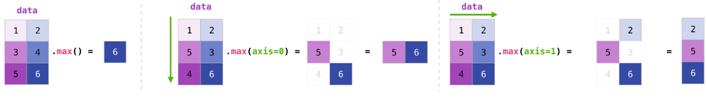

[Learn more about basic operations here.](https://numpy.org/doc/stable/user/quickstart.html#basic-operations)

### Broadcasting

Broadcasting allows us to perform vectorized operations between two arrays even if their dimensions do not match by creating implicit multidimensional grids. You already learned about ufuncs in the previous section where we performed element-wise addition between a scalar and a multidimensional array, which is just one example of broadcasting.

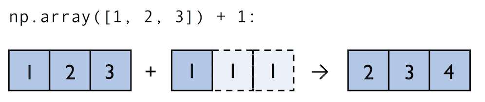

```python
ary1 = np.array([1, 2, 3])

ary3 = np.array([[4, 5, 6],
                 [7, 8, 9]])

ary3 + ary1 # similarly, ary1 + ary3
```

```
array([[ 5,  7,  9],
       [ 8, 10, 12]])
```

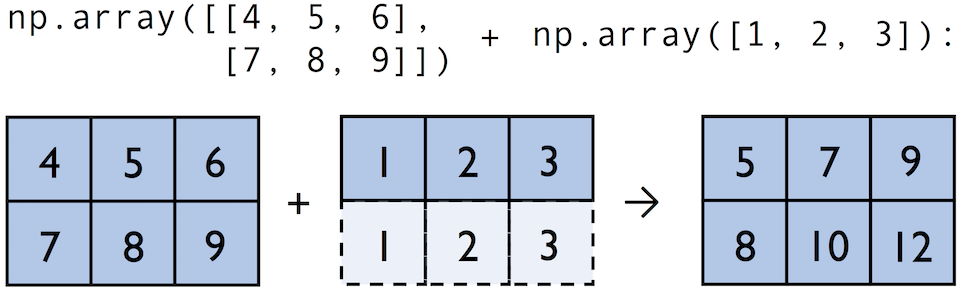

[Learn more about broadcasting here.](https://numpy.org/doc/stable/user/basics.broadcasting.html)

### Advanced Indexing -- Memory Views and Copies

In the previous sections, we have used basic indexing and slicing routines. It is important to note that basic integer-based indexing and slicing create so-called *views* of NumPy arrays in memory. Working with views can be highly desirable since it avoids making unnecessary copies of arrays to save memory resources. To illustrate the concept of memory views, let us walk through a simple example where we access the first row in an array, assign it to a variable, and modify that variable:

```python
ary = np.array([[1, 2, 3],
                [4, 5, 6]])

first_row = ary[0]
first_row += 99
ary
```

```
array([[100, 101, 102],
       [  4,   5,   6]])
```

As we can see in the example above, changing the value of `first_row` also affected the original array. The reason for this is that `ary[0]` created a view of the first row in `ary`, and its elements were then incremented by 99. The same concept applies to slicing operations:

```python
ary = np.array([[1, 2, 3],
                [4, 5, 6]])

first_row = ary[:1]
first_row += 99
ary
```

```
array([[100, 101, 102],
       [  4,   5,   6]])
```

```python
ary = np.array([[1, 2, 3],
                [4, 5, 6]])

center_col = ary[:, 1]
center_col += 99
ary
```

```
array([[  1, 101,   3],
       [  4, 104,   6]])
```

If we are working with NumPy arrays, it is always important to be aware that **slicing creates views** -- sometimes it is desirable since it can speed up our code by avoiding to create unnecessary copies in memory. However, in certain scenarios we want force a copy of an array; we can do this via the `copy` method as shown below:

```python
ary = np.array([[1, 2, 3],
                [4, 5, 6]])

second_row = ary[1].copy()
second_row += 99
ary
```

```
array([[1, 2, 3],
       [4, 5, 6]])
```

[Learn more about copies and views here.](https://numpy.org/doc/stable/user/basics.copies.html)

In addition to basic single-integer indexing and slicing operations, NumPy supports advanced indexing routines called *fancy* indexing. Via fancy indexing, we can use tuple or list objects of non-contiguous integer indices to return desired array elements. Since fancy indexing can be performed with non-contiguous sequences, it cannot return a view -- a contiguous slice from memory. Thus, fancy indexing always returns a copy of an array -- it is important to keep that in mind. The following code snippets show some fancy indexing examples:

```python
ary = np.array([[1, 2, 3],
                [4, 5, 6]])

ary[:, [0, 2]] # first and last column
```

```
array([[1, 3],
       [4, 6]])
```

```python
this_is_a_copy = ary[:, [0, 2]]
this_is_a_copy += 99
ary
```

```
array([[1, 2, 3],
       [4, 5, 6]])
```

```python
ary[:, [2, 0]] # last and first column
```

```
array([[3, 1],
       [6, 4]])
```

Finally, we can also use Boolean masks for indexing -- that is, arrays of `True` and `False` values. Consider the following example, where we return all values in the array that are greater than 3:

```python
ary = np.array([[1, 2, 3],
                [4, 5, 6]])

greater3_mask = ary > 3
greater3_mask
```

```
array([[False, False, False],
       [ True,  True,  True]])
```

Using these masks, we can select elements given our desired criteria:

```python
ary[greater3_mask]
```

```
array([4, 5, 6])
```

We can also chain different selection criteria using the logical *and* operator '&' or the logical *or* operator '|'. The example below demonstrates how we can select array elements that are greater than 3 and divisible by 2:

```python
ary[(ary > 3) & (ary % 2 == 0)]
```

```
array([4, 6])
```

Note that indexing using Boolean arrays is also considered "fancy indexing" and thus returns a copy of the array.

[Learn more about advanced indexing here.](https://numpy.org/doc/stable/user/quickstart.html#advanced-indexing-and-index-tricks)

### Reshaping Arrays

In practice, we often run into situations where existing arrays do not have the *right* shape to perform certain computations. The size of NumPy arrays is fixed, but the shape is not. NumPy provides a `reshape` method that allow us to obtain a view of an array with a different shape.

For example, we can reshape a one-dimensional array into a two-dimensional one using `reshape` as follows:

```python
ary1d = np.array([1, 2, 3, 4, 5, 6])
ary2d_view = ary1d.reshape(2, 3)
ary2d_view
```

```
array([[1, 2, 3],
       [4, 5, 6]])
```

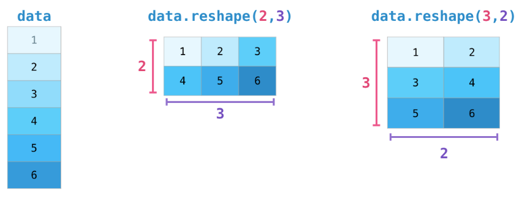

We do not need to specify the number of elements in each axis; NumPy is smart enough to figure out how many elements to put along an axis if only one axis is unspecified (by using the placeholder `-1`):

```python
ary1d.reshape(2, -1)
```

```
array([[1, 2, 3],
       [4, 5, 6]])
```

```python
ary1d.reshape(-1, 2)
```

```
array([[1, 2],
       [3, 4],
       [5, 6]])
```

We can, of course, also use `reshape` to flatten an array:

```python
ary = np.array([[[1, 2, 3],
                [4, 5, 6]]])

ary.reshape(-1) # equivalent to ary.reshape(6)
```

```
array([1, 2, 3, 4, 5, 6])
```

Sometimes, we are interested in merging different arrays. Unfortunately, there is no efficient way to do this without creating a new array, since NumPy arrays have a fixed size. While combining arrays should be avoided if possible -- for reasons of computational efficiency -- it is sometimes necessary. To combine two or more array objects, we can use NumPy's `concatenate` function as shown in the following examples:

```python
ary = np.array([1, 2, 3])

np.concatenate((ary, ary))
```

```
array([1, 2, 3, 1, 2, 3])
```

```python
ary = np.array([[1, 2, 3]])

# stack along the first axis (here: rows)
np.concatenate((ary, ary), axis=0)
```

```
array([[1, 2, 3],
       [1, 2, 3]])
```

```python
# stack along the second axis (here: column)
np.concatenate((ary, ary), axis=1)
```

```
array([[1, 2, 3, 1, 2, 3]])
```

[Learn more about shape manipulation here.](https://numpy.org/doc/stable/user/quickstart.html#shape-manipulation)

### Comparison Operators and Masks

In the previous section, we already briefly introduced the concept of Boolean masks in NumPy. Boolean masks are `bool`-type arrays (storing `True` and `False` values) that have the same shape as a certain target array. For example, consider the following 4-element array below. Using comparison operators (such as `<`, `>`, `<=`, and `>=`), we can create a Boolean mask of that array which consists of `True` and `False` elements depending on whether a condition is met in the target array (here: `ary`):

```python
ary = np.array([1, 2, 3, 4])
mask = ary > 2
mask
```

```
array([False, False,  True,  True])
```

Once we created such a Boolean mask, we can use it to select entries from the array that match the condition:

```python
ary[mask]
```

```
array([3, 4])
```

Beyond the selection of elements from an array, Boolean masks can also come in handy when we want to count how many elements in an array meet a certain condition:

```python
mask
```

```
array([False, False,  True,  True])
```

```python
mask.sum()
```

```
2
```

A related, useful function to assign values to specific elements in an array is the `np.where` function. In the example below, we assign a 1 to all values in the array that are greater than 2 -- and 0, otherwise:

```python
np.where(ary > 2, 1, 0)
```

```
array([0, 0, 1, 1])
```

There are also so-called bit-wise operators that we can use to specify more complex selection criteria:

```python
ary = np.array([1, 2, 3, 4])
mask = ary > 2
ary[mask] = 1
ary[~mask] = 0
ary
```

```
array([0, 0, 1, 1])
```

The `~` operator in the example above is one of the logical operators in NumPy:

- And: `&` or `np.bitwise_and`
- Or: `|` or `np.bitwise_or`
- Not: `~` or `np.bitwise_not`

These logical operators allow us to chain an arbitrary number of conditions to create even more "complex" Boolean masks. For example, using the "Or" operator, we can select all elements that are greater than 3 or smaller than 2 as follows:

```python
ary = np.array([1, 2, 3, 4])

(ary > 3) | (ary < 2)
```

```
array([ True, False, False,  True])
```

And, for example, to negate the condition, we can use the `~` operator:

```python
~((ary > 3) | (ary < 2))
```

```
array([False,  True,  True, False])
```

[Learn more about the `np.where` function here.](https://numpy.org/doc/stable/reference/generated/numpy.where.html)

#### Acknowledgment

This material was adapted from a notebook created by Sebastian Raschka that you can find [here](https://github.com/rasbt/stat479-machine-learning-fs19/blob/master/04_sci-python/04-scipython__code.ipynb).